# PCIT-CoS-Waitlist RCT Paper 1: MM Nonattuned

Nancy Briggs

2024-04-29

### MM Nonattuned

Output run on 2024-04-29

Variables: MM_nonattuned T2_nonattuned T3_nonattuned

#### Descriptives

| group | time | n | mean | sd | median | min | max |
| --- | --- | --- | --- | --- | --- | --- | --- |
| 1 | 1 | 30 | 3.633 | 2.834 | 3.5 | 0 | 12 |
| 1 | 2 | 23 | 1.391 | 1.948 | 1.0 | 0 | 8 |
| 1 | 3 | 13 | 2.231 | 3.193 | 1.0 | 0 | 11 |
| 2 | 1 | 28 | 3.321 | 3.732 | 2.0 | 0 | 17 |
| 2 | 2 | 12 | 4.833 | 4.324 | 3.0 | 0 | 15 |
| 2 | 3 | 3 | 3.667 | 0.577 | 4.0 | 3 | 4 |
| 3 | 1 | 30 | 3.667 | 5.168 | 2.5 | 0 | 27 |
| 3 | 2 | 26 | 5.308 | 7.455 | 4.0 | 0 | 32 |
| 3 | 3 | 1 | 8.000 | NA | 8.0 | 8 | 8 |

There is 1 G3 observation with data. Here is the table having recoded that value to missing.

| group | time | n | mean | sd | median | min | max |
| --- | --- | --- | --- | --- | --- | --- | --- |
| 1 | 1 | 30 | 3.633 | 2.834 | 3.5 | 0 | 12 |
| 1 | 2 | 23 | 1.391 | 1.948 | 1.0 | 0 | 8 |
| 1 | 3 | 13 | 2.231 | 3.193 | 1.0 | 0 | 11 |
| 2 | 1 | 28 | 3.321 | 3.732 | 2.0 | 0 | 17 |
| 2 | 2 | 12 | 4.833 | 4.324 | 3.0 | 0 | 15 |
| 2 | 3 | 3 | 3.667 | 0.577 | 4.0 | 3 | 4 |
| 3 | 1 | 30 | 3.667 | 5.168 | 2.5 | 0 | 27 |
| 3 | 2 | 26 | 5.308 | 7.455 | 4.0 | 0 | 32 |
| 3 | 3 | 0 | NaN | NA | NA | Inf | -Inf |

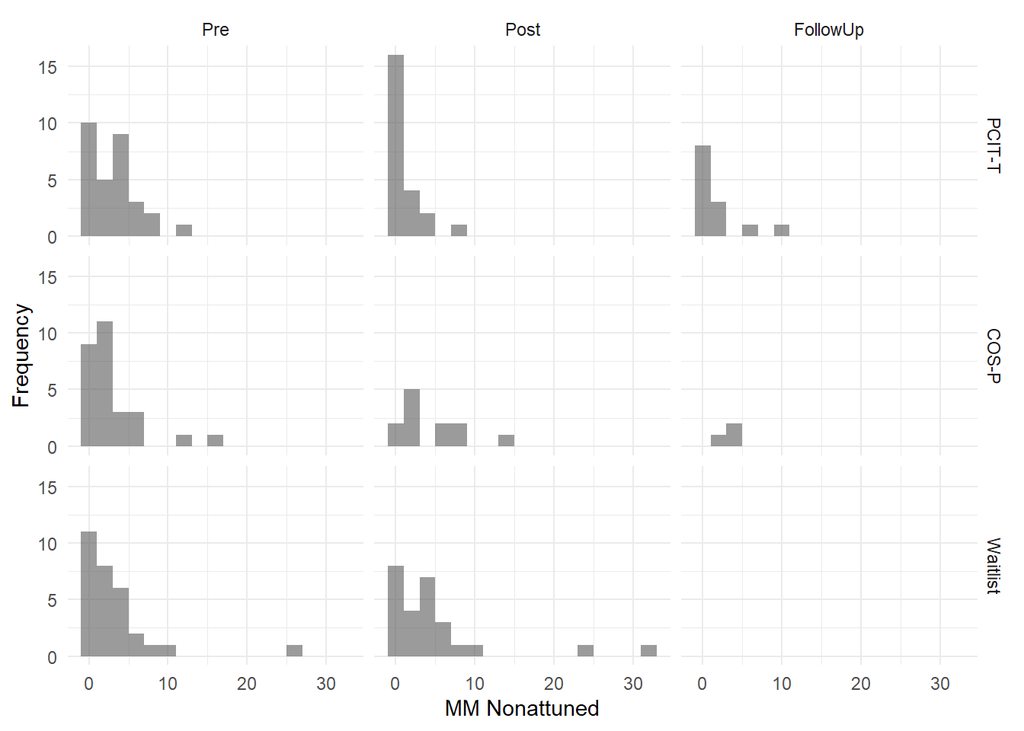

#### Model & Results

A linear mixed model with random effect for individual and fixed effects of group, time and the interaction was run. Estimated marginal means were obtained, and contrasts specified to test Hypothesis 1 and Hypothesis 2.

```
## fixed-effect model matrix is rank deficient so dropping 1 column / coefficient
## fixed-effect model matrix is rank deficient so dropping 1 column / coefficient
```

```
## refitting model(s) with ML (instead of REML)
```

|  | Effect | npar | AIC | BIC | logLik | deviance | Chisq | Df | Pr(>Chisq) |
| --- | --- | --- | --- | --- | --- | --- | --- | --- | --- |
| result0 | Intercept | 3 | 945.370 | 954.687 | -469.685 | 939.370 | NA | NA | NA |
| result1 | Group | 5 | 946.380 | 961.910 | -468.190 | 936.380 | 2.990 | 2 | 0.224 |
| result2 | Time | 7 | 949.758 | 971.500 | -467.879 | 935.758 | 0.622 | 2 | 0.733 |
| result3 | Group*Time | 10 | 941.756 | 972.816 | -460.878 | 921.756 | 14.002 | 3 | 0.003 |

This is the ANOVA table for the model. p-values are likelihood ratio tests for adding the new term to the model just before. A p-value <0.05 indicates that adding that term results in better model fit. The most important p-value is the interaction p-value. Here, there is evidence that the pattern of change over time is different among the groups (p=0.003).

```r
summary(result3)
```

```
## Linear mixed model fit by REML. t-tests use Satterthwaite's method [
## lmerModLmerTest]
## Formula: outcome ~ group * time + (1 | id)
##    Data: dat
##
## REML criterion at convergence: 908.3
##
## Scaled residuals:
##     Min      1Q  Median      3Q     Max
## -1.7917 -0.4260 -0.1448  0.3361  3.8395
##
## Random effects:
##  Groups   Name        Variance Std.Dev.
##  id       (Intercept) 11.995   3.463
##  Residual              8.338   2.888
## Number of obs: 165, groups:  id, 88
##
## Fixed effects:
##               Estimate Std. Error        df t value Pr(>|t|)
## (Intercept)    3.63333    0.82327 118.56114   4.413 2.26e-05 ***
## group2        -0.31190    1.18489 118.56114  -0.263 0.792827
## group3         0.03333    1.16429 118.56114   0.029 0.977208
## time2         -2.27879    0.83088  81.41048  -2.743 0.007493 **
## time3         -1.43561    1.03571  84.65615  -1.386 0.169355
## group2:time2   3.63619    1.38464  88.62029   2.626 0.010175 *
## group3:time2   4.01814    1.14639  80.04174   3.505 0.000751 ***
## group2:time3  -0.07427    2.27102  89.99275  -0.033 0.973982
## ---
## Signif. codes:  0 '***' 0.001 '**' 0.01 '*' 0.05 '.' 0.1 ' ' 1
##
## Correlation of Fixed Effects:
##             (Intr) group2 group3 time2  time3  grp2:2 grp3:2
## group2      -0.695
## group3      -0.707  0.491
## time2       -0.406  0.282  0.287
## time3       -0.326  0.226  0.230  0.381
## group2:tim2  0.244 -0.351 -0.172 -0.600 -0.229
## group3:tim2  0.294 -0.205 -0.416 -0.725 -0.276  0.435
## group2:tim3  0.149 -0.214 -0.105 -0.174 -0.456  0.273  0.126
## fit warnings:
## fixed-effect model matrix is rank deficient so dropping 1 column / coefficient
```

#### Estimated Means & Change

Estimated means for each Treatment and Time are presented. In addition, within-group change between time points is presented with 95% CIs.

NOTE: TO MAKE THIS RUN MORE QUICKLY< BOOTSTRAPPING WAS RESTRICTED TO 10 REPLICATIONS (BECAUSE WE AREN”T REPORTING BOOTSTRAPPED CIs FOR THE EFFECT SIZE.)

##### Group mean difference at each timepoint

Effect sizes all calculated by the pooled T1 SD of the outcome. Adjusted p-value from Bonferroni correction.

Group Differences at Each Time Point

| Group Difference | Time | Mean | SE | t | p | adj p | Lower CL | Upper CL | Effect Size | Lower CL | Upper CL |
| --- | --- | --- | --- | --- | --- | --- | --- | --- | --- | --- | --- |
| 1 - 2 | 1 | 0.312 | 1.185 | 0.263 | 0.963 | 1.000 | -2.501 | 3.125 | 0.095 | -0.105 | -0.105 |
| 1 - 3 | 1 | -0.033 | 1.164 | -0.029 | 1.000 | 1.000 | -2.797 | 2.731 | -0.010 | -0.436 | -0.436 |
| 2 - 3 | 1 | -0.345 | 1.185 | -0.291 | 0.954 | 1.000 | -3.158 | 2.468 | -0.105 | -0.331 | -0.331 |
| 1 - 2 | 2 | -3.324 | 1.478 | -2.250 | 0.066 | 0.078 | -6.821 | 0.173 | -1.008 | -0.574 | -0.574 |
| 1 - 3 | 2 | -4.051 | 1.250 | -3.242 | 0.004 | 0.005 | -7.013 | -1.089 | -1.228 | -0.880 | -0.880 |
| 2 - 3 | 2 | -0.727 | 1.455 | -0.500 | 0.871 | 1.000 | -4.170 | 2.716 | -0.220 | -0.305 | -0.305 |
| 1 - 2 | 3 | 0.386 | 2.336 | 0.165 | 0.985 | 1.000 | -5.153 | 5.925 | 0.117 | 1.405 | 1.405 |
| 1 - 3 | 3 | NA | NA | NA | NA | NA | NA | NA | NA | NA | NA |
| 2 - 3 | 3 | NA | NA | NA | NA | NA | NA | NA | NA | NA | NA |

* Effect size scaled by pooled T1 SD  
† ES 95% Bootstrapped Percentile CI limits  
‡ If you want a positive ES (and it is calculated as negative), be sure to switch the signs and positions of the lower and upper CIs.

##### Change within each group

Within-Group Change and Effect Sizes

| Change | Group | Mean | SE | t | p | adj p | Lower CL | Upper CL | Effect Size | Lower CL | Upper CL |
| --- | --- | --- | --- | --- | --- | --- | --- | --- | --- | --- | --- |
| 1 - 2 | 1 | 2.279 | 0.832 | 2.738 | 0.021 | 0.023 | 0.291 | 4.267 | 0.691 | 0.112 | 0.112 |
| 1 - 3 | 1 | 1.436 | 1.039 | 1.382 | 0.355 | 0.512 | -1.044 | 3.915 | 0.435 | -0.253 | -0.253 |
| 2 - 3 | 1 | -0.843 | 1.054 | -0.800 | 0.704 | 1.000 | -3.362 | 1.675 | -0.256 | -0.364 | -0.364 |
| 1 - 2 | 2 | -1.357 | 1.113 | -1.220 | 0.445 | 0.677 | -4.009 | 1.294 | -0.412 | -0.358 | -0.358 |
| 1 - 3 | 2 | 1.510 | 2.031 | 0.743 | 0.738 | 1.000 | -3.331 | 6.351 | 0.458 | 1.257 | 1.257 |
| 2 - 3 | 2 | 2.867 | 2.068 | 1.386 | 0.353 | 0.508 | -2.068 | 7.802 | 0.869 | 1.615 | 1.615 |
| 1 - 2 | 3 | -1.739 | 0.791 | -2.200 | 0.078 | 0.092 | -3.629 | 0.150 | -0.527 | -0.332 | -0.332 |
| 1 - 3 | 3 | NA | NA | NA | NA | NA | NA | NA | NA | NA | NA |
| 2 - 3 | 3 | NA | NA | NA | NA | NA | NA | NA | NA | NA | NA |

* Effect size scaled by pooled T1 SD  
† ES 95% Bootstrapped Percentile CI limits  
‡ If you want a positive ES (and it is calculated as negative), be sure to switch the signs and positions of the lower and upper CIs.

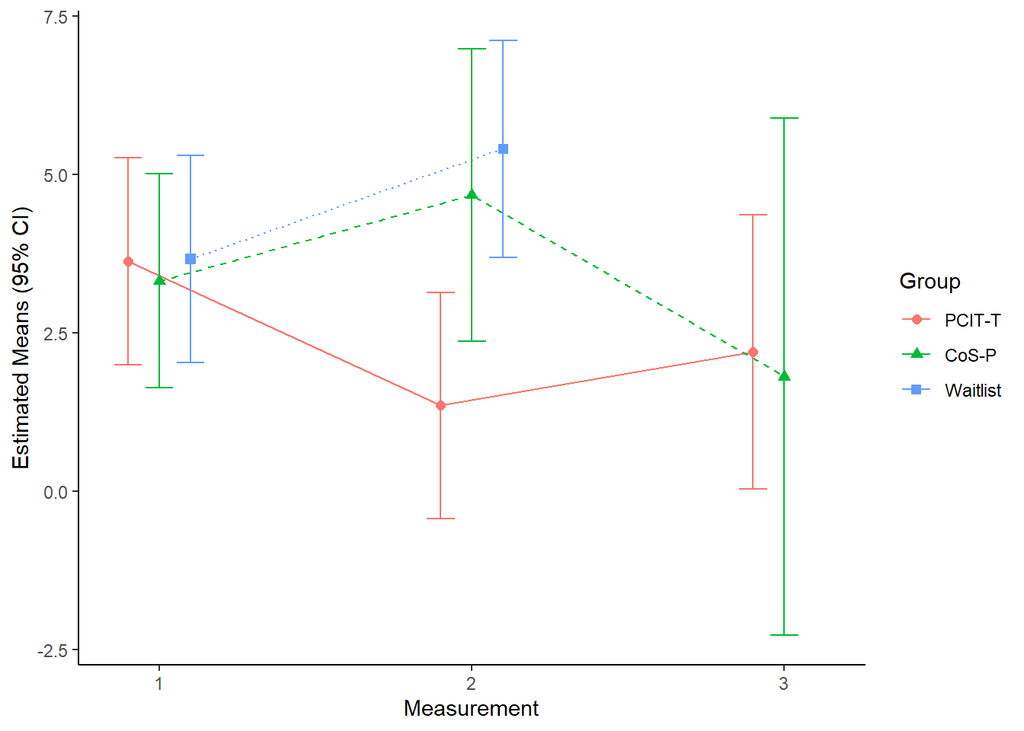

#### Hypothesis 1

We hypothesize that from baseline (‘T1’) to post-treatment/waitlist (‘T2’) there will be a gradient effect, whereby parent-child dyads who receive PCIT-T will show the greatest gains and parent-child dyads who receive no treatment will show the least gains. For the outcome, then, the null hypothesis is:

$H_0: \text {mean change}(\text{PCIT-T}) = \text {mean change}(\text{CoS-P}) = \text {mean change}(\text{Waitlist})$ $H_A: \text {mean change}(\text{PCIT-T}) > \text {mean change}(\text{CoS-P}) > \text {mean change}(\text{Waitlist})$

This is a joint hypothesis test.

First, confirming that the ordering of the means is as hypothesized:

```
## group = 1:
##  contrast estimate    SE   df t.ratio p.value
##  1 - 2       2.279 0.832 79.5   2.738  0.0206
##  1 - 3       1.436 1.039 82.7   1.382  0.3549
##  2 - 3      -0.843 1.054 78.3  -0.800  0.7042
##
## group = 2:
##  contrast estimate    SE   df t.ratio p.value
##  1 - 2      -1.357 1.113 91.0  -1.220  0.4446
##  1 - 3       1.510 2.031 89.6   0.743  0.7384
##  2 - 3       2.867 2.068 83.4   1.386  0.3526
##
## group = 3:
##  contrast estimate    SE   df t.ratio p.value
##  1 - 2      -1.739 0.791 76.6  -2.200  0.0775
##  1 - 3      nonEst    NA   NA      NA      NA
##  2 - 3      nonEst    NA   NA      NA      NA
##
## Degrees-of-freedom method: kenward-roger
## P value adjustment: tukey method for comparing a family of 3 estimates
```

So, the mean change for PCITT > COSP > Waitlist.

Now, to get the p-value associated with the joint hypothesis.

```
##   (Intercept) group2 group3 time2 time3 group2:time2 group3:time2 group2:time3
## 1           0      0      0     0     0           -1            0            0
## 2           0      0      0     0     1            0            1            0
```

```
##
##   General Linear Hypotheses
##
## Linear Hypotheses:
##        Estimate
## 1 == 0   -3.636
## 2 == 0    2.583
##
## Global Test:
##       F DF1 DF2  Pr(>F)
## 1 4.528   2 155 0.01227
```

p=0.0123. We have evidence that this the change from T1 to T2 is greater for G1 then G2 and the change in G2 is greater than in G3.

#### Hypothesis 2

##### Change from T2-T3

There will be a gradient of size of change from T2 to T3 such that the change in the PCIT-T group > the change in the CoS-P group. This isn’t really a gradient; it’s just 1 hypothesis.

First, the change in PCITT and COSP from time 2 to time 3:

```
## group = 1:
##  time emmean    SE  df lower.CL upper.CL
##  1      3.63 0.823 117   2.0029     5.26
##  2      1.35 0.903 137  -0.4303     3.14
##  3      2.20 1.096 157   0.0331     4.36
##
## group = 2:
##  time emmean    SE  df lower.CL upper.CL
##  1      3.32 0.852 117   1.6338     5.01
##  2      4.68 1.170 157   2.3679     6.99
##  3      1.81 2.063 117  -2.2745     5.90
##
## group = 3:
##  time emmean    SE  df lower.CL upper.CL
##  1      3.67 0.823 117   2.0362     5.30
##  2      5.41 0.864 128   3.6959     7.12
##  3    nonEst    NA  NA       NA       NA
##
## Degrees-of-freedom method: kenward-roger
## Confidence level used: 0.95
```

```
## group = 1:
##  contrast estimate    SE   df lower.CL upper.CL
##  1 - 2       2.279 0.832 79.5    0.291     4.27
##  1 - 3       1.436 1.039 82.7   -1.044     3.91
##  2 - 3      -0.843 1.054 78.3   -3.362     1.68
##
## group = 2:
##  contrast estimate    SE   df lower.CL upper.CL
##  1 - 2      -1.357 1.113 91.0   -4.009     1.29
##  1 - 3       1.510 2.031 89.6   -3.331     6.35
##  2 - 3       2.867 2.068 83.4   -2.068     7.80
##
## group = 3:
##  contrast estimate    SE   df lower.CL upper.CL
##  1 - 2      -1.739 0.791 76.6   -3.629     0.15
##  1 - 3      nonEst    NA   NA       NA       NA
##  2 - 3      nonEst    NA   NA       NA       NA
##
## Degrees-of-freedom method: kenward-roger
## Confidence level used: 0.95
## Conf-level adjustment: tukey method for comparing a family of 3 estimates
```

```r
## Specify contrast matrices
# Hyp1 is 1 df test
# could use alternative="less" ir alternative="greater" in glht
hyp2   <- matrix(c(0, 0,0, 0,0, -1,0,1 ),1)
hyp2F <- glht(result3, linfct = hyp2)
summary(hyp2F)
```

```
##
##   Simultaneous Tests for General Linear Hypotheses
##
## Fit: lmer(formula = outcome ~ group * time + (1 | id), data = dat)
##
## Linear Hypotheses:
##        Estimate Std. Error z value Pr(>|z|)
## 1 == 0   -3.710      2.314  -1.603    0.109
## (Adjusted p values reported -- single-step method)
```

```r
s<-summary(hyp2F, test = Ftest())
#also see this webpage for more on contrasts https://rcompanion.org/rcompanion/h_01.html



## Extract pvaue for evidence / no evidence
evidence = ifelse(s$test$pvalue<0.05, "evidence", "no evidence")
```

Change in G1 from T2 to T3: -0.843

Change in G2 from T2 to T3: 2.867

##### Change from T1-T3

```
##
##   General Linear Hypotheses
##
## Linear Hypotheses:
##        Estimate
## 1 == 0 -0.07427
##
## Global Test:
##         F DF1 DF2 Pr(>F)
## 1 0.00107   1 155  0.974
```

Change in G1 from T1 to T3: 1.436

Change in G2 from T1 to T3: 1.51

p=0.974. We have no evidence that the change from T1 to T3 is different for G1 and G2

#### Residuals

Assumptions of the model are met for the log-transformed data.

*Raw data*

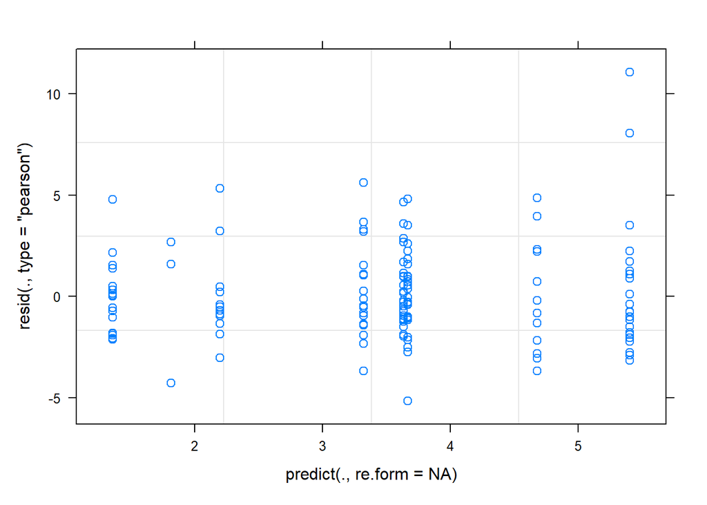

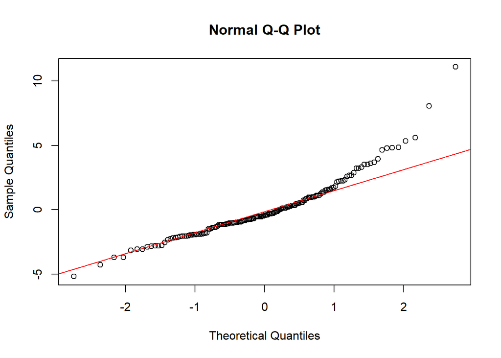

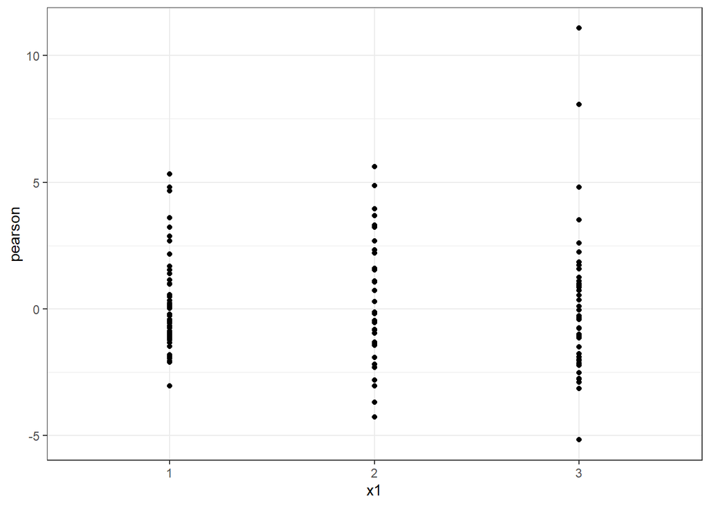

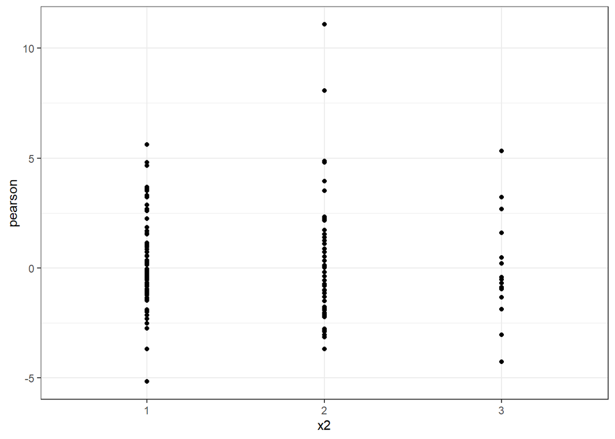

You can see that the residuals show a pattern of much larger values in the positive direction and skew in the QQ plot.

*Log data*

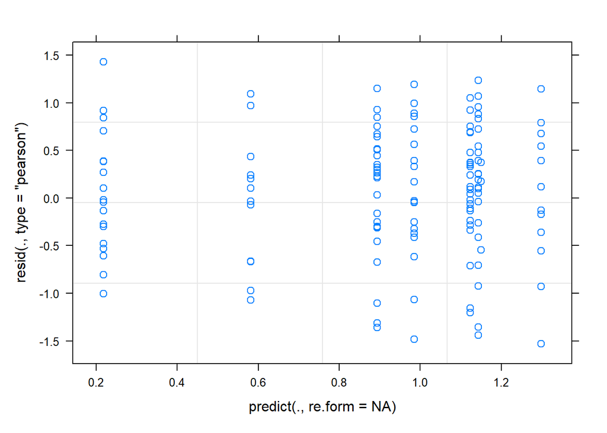

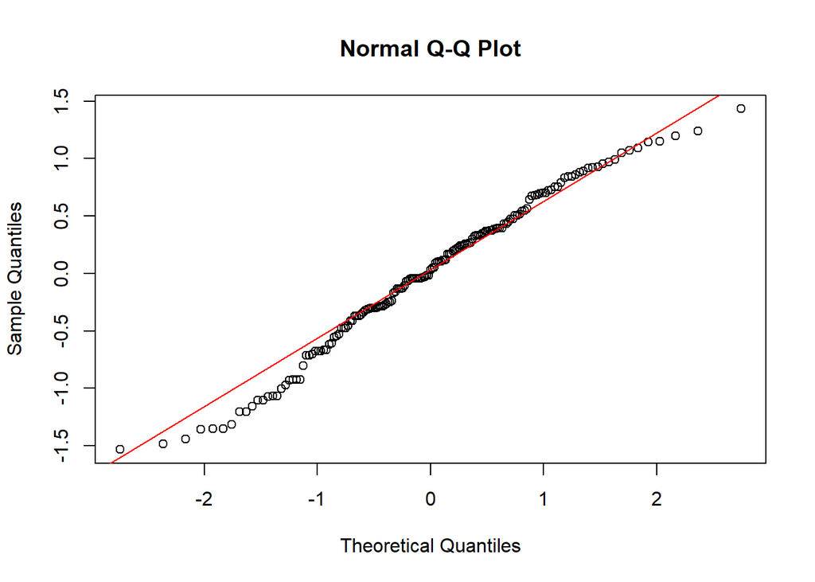

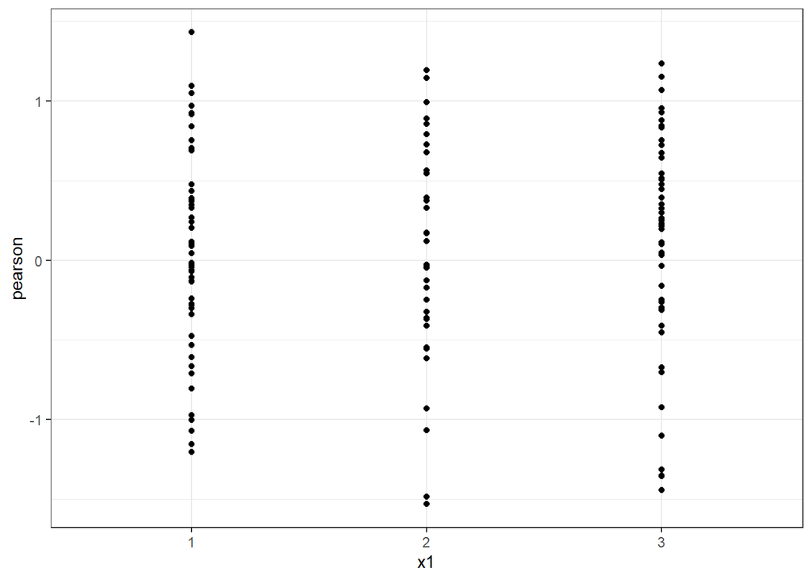

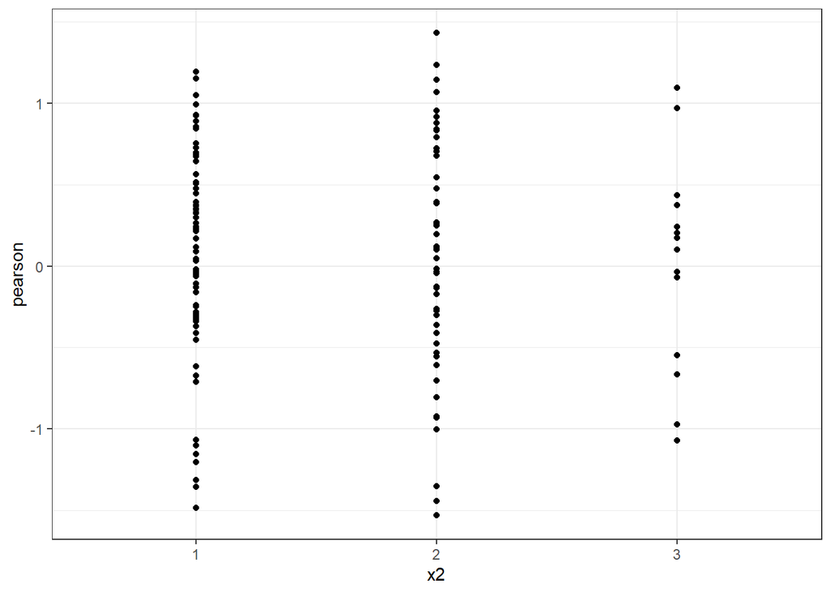

Residuals are much more symmetric around 0 and a nicer QQplot

```r
rm(list = ls())
```